# Cluster tendency using unsupervised random forest 2

Yi Chen

2024-09-05

# 1 Introduction

An alternative to using the Hopkins statistic is to use metrics innate to the random forest algorithm to estimate clustering tendency. Similar to the Hopkins statistic, we generate the null distribution of random data and compare our new statistic to that null distribution. The three things I want to test here are the following:

1. The prediction accuracy of unsupervised random forest
2. The mean decrease accuracy of the features used in unsupervised random forest (distribution vs maximum)
3. The decrease in (Gini) node impurity of the features (distribution vs maximum)

# 2 Running unsupervised random forest

The two main parameters I expect to affect accuracy, mean decrease accuracy, and Gini impurity are the number of features and the number of samples.

```r
sample_data_set = function(x, m=nrow(x)) {
    n = nrow(x)
    x = x %>% mutate(across(everything(),
        function(.x) {
            if(all(.x == 0 | .x == 1)) { # binary
                return(sample(c(0, 1), size=n, replace=T))
            } else if(is.numeric(.x)) { # continuous
                return(runif(n, min=min(.x), max=max(.x)))
            } else if(is.factor(.x)) { # categorical
                return(factor(sample(unique(.x), size=n, replace=T)))
            } else { # other?
                return(sample(.x, size=n, replace=T))
            }
        })) %>%
        slice_sample(n=m)
    x
}
```

```r
#' @param m number of rows
#' @param d number of columns
#' @param type one of `cont` or `cat` for continuous or categorical random data
#' @param num.cat number of categories for categorical random data; if length of num.cat is equal
#'        to d, then the number of categories for column i be num.cat[i]
random_data_set = function(m, d, type=c('cont', 'cat'), num.cat=3) {
    type = match.arg(type)
    tmp = NULL
    if(type == 'cont') {
        tmp = do.call('data.frame',
                      lapply(1:d, function(.x) runif(n=m)))
        colnames(tmp) = paste0('rand_cont_runif_', 1:d)
    } else if(type == 'cat') {
        if(length(num.cat) == d) {
            num.cat = num.cat
        } else {
            num.cat = rep(num.cat, d)
        }
        tmp = do.call('data.frame',
                      lapply(num.cat, function(.x) factor(sample(1:.x, size=m, replace=T))))
        colnames(tmp) = paste0('rand_cat', num.cat, '_', 1:d)
    }
    return(tmp)
}
```

```r
usrf = function(x, seed=42, ntree=1000) {
    set.seed(seed)
    x_fake = x %>% mutate(across(everything(), ~ sample(.x, size=nrow(x))))
    rf = randomForest(x=rbind(x, x_fake),
                      y=factor(c(rep('real', nrow(x)), rep('fake', nrow(x_fake)))),
                      importance=T,
                      keep.forest=F,
                      ntree=ntree
                      )
    rf
}
```

# 3 Stability of accuracy over trees

```r
stability = cache_rds({
    mclapply(4:20, function(d) {
        stderrp('Starting run with d = ', d)
        ds = random_data_set(m=50, d=d, type='cont')
        usrf(ds, seed=42, ntree=50000)
    }, mc.cores=3)
}, rerun=F, clean=T)
```

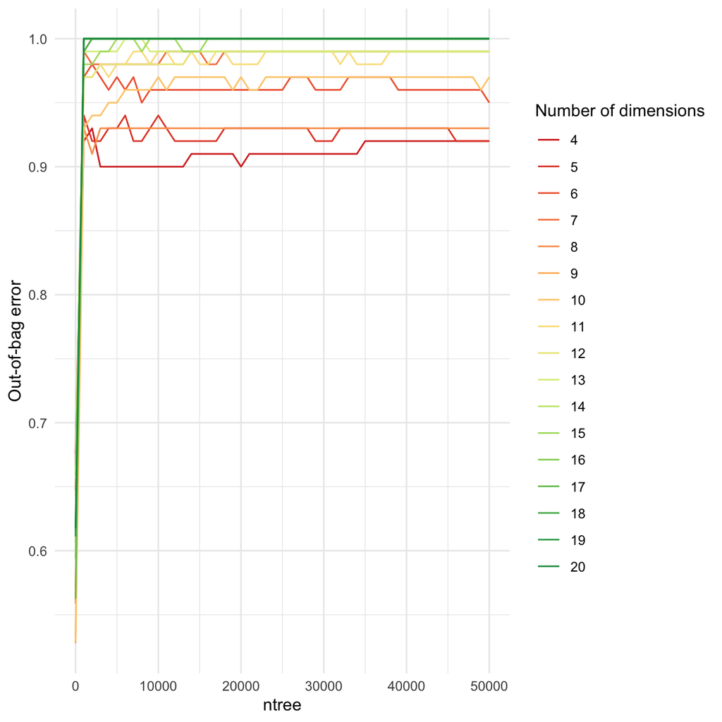

```r
tmp = bind_rows(lapply(seq_along(stability), function(i) {
    rf = stability[[i]]
    sample_points = c(1, seq(from=1000, to=50000, by=1000))
    data.frame(ntree=sample_points,
               d=(4:20)[i],
               err=rf$err.rate[sample_points, 'OOB'],
               real.err=rf$err.rate[sample_points, 'real'],
               fake.err=rf$err.rate[sample_points, 'fake']
    )
}))
mycolors <- colorRampPalette(RColorBrewer::brewer.pal(8, "RdYlGn"))(length(stability))
ggplot(tmp) +
    geom_line(aes(x=ntree, y=err, color=factor(d))) +
    scale_color_manual('Number of dimensions', values=mycolors) +
    ylab("Out-of-bag error") +
    theme_minimal()
```

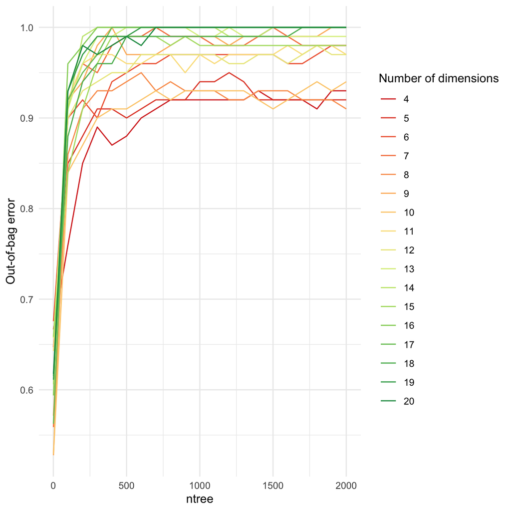

```r
tmp = bind_rows(lapply(seq_along(stability), function(i) {
    rf = stability[[i]]
    sample_points = c(1, seq(from=100, to=2000, by=100))
    data.frame(ntree=sample_points,
               d=(4:20)[i],
               err=rf$err.rate[sample_points, 'OOB'],
               real.err=rf$err.rate[sample_points, 'real'],
               fake.err=rf$err.rate[sample_points, 'fake']
    )
}))
mycolors <- colorRampPalette(RColorBrewer::brewer.pal(8, "RdYlGn"))(length(stability))
ggplot(tmp) +
    geom_line(aes(x=ntree, y=err, color=factor(d))) +
    scale_color_manual('Number of dimensions', values=mycolors) +
    ylab("Out-of-bag error") +
    theme_minimal()
```

# 4 Simulated Multivariate-normal data

## 4.1 Test 1 - means 0 and 1

Here, I simulate a data set using a multivariate normal distribution over 100 dimensions with 0 covariance. One class has variable means of 0, and the other class has variable means of 1. We use a sample size of 50 for each class.

```r
set.seed(42)
d = 100
tmp = mvrnorm(n=50, mu=rep(0, d), Sigma=diag(rep(1, d)))
tmp2 = mvrnorm(n=50, mu=rep(1, d), Sigma=diag(rep(1, d)))
sim_2class = data.frame(rbind(tmp, tmp2))
sim_2class.y = factor(c(rep('class1', 50), rep('class2', 50)))

test_d = c(3, 5, 7, seq(from=10, to=100, by=10))

sim_2class_res = cache_rds({
    lapply(test_d, function(d) {
        x = sim_2class[,1:d]
        usrf(x, ntree=1000)
    })
}, rerun=F, clean=T)

tmp = data.frame(d=test_d,
           err=sapply(sim_2class_res, function(x) x$err.rate[x$ntree,1])
)
p1 = ggplot(tmp) +
    geom_point(aes(x=d, y=err)) +
    xlab("Number of dimensions") +
    ylab("OOB error") +
    theme_minimal()
```

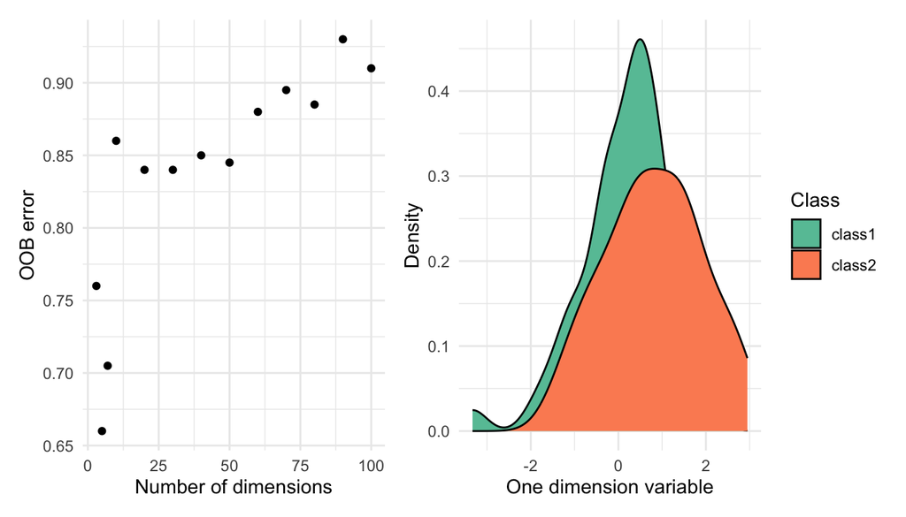

```r
tmp = data.frame(x=sim_2class[,1], y=sim_2class.y)
p2 = ggplot(tmp) +
    geom_density(aes(x=x, fill=y)) +
    xlab("One dimension variable") +
    ylab("Density") +
    scale_fill_brewer(name="Class", palette="Set2") +
    theme_minimal()
p1 + p2
```

## 4.2 Test 2 - means 0 and 3

Here, I simulate a data set using a multivariate normal distribution over 100 dimensions with 0 covariance. One class has variable means of 0, and the other class has variable means of 3. We use a sample size of 50 for each class.

```r
library(MASS)
set.seed(42)
d = 100
tmp = mvrnorm(n=50, mu=rep(0, d), Sigma=diag(rep(1, d)))
tmp2 = mvrnorm(n=50, mu=rep(3, d), Sigma=diag(rep(1, d)))
sim_2class = data.frame(rbind(tmp, tmp2))
sim_2class.y = factor(c(rep('class1', 50), rep('class2', 50)))

test_d = c(3, 5, 7, seq(from=10, to=100, by=10))

sim_2class_res = cache_rds({
    lapply(test_d, function(d) {
        x = sim_2class[,1:d]
        usrf(x, ntree=1000)
    })
}, rerun=F, clean=T)

tmp = data.frame(d=test_d,
           err=sapply(sim_2class_res, function(x) x$err.rate[x$ntree,1])
)
p1 = ggplot(tmp) +
    geom_point(aes(x=d, y=err)) +
    xlab("Number of dimensions") +
    ylab("OOB error") +
    theme_minimal()
```

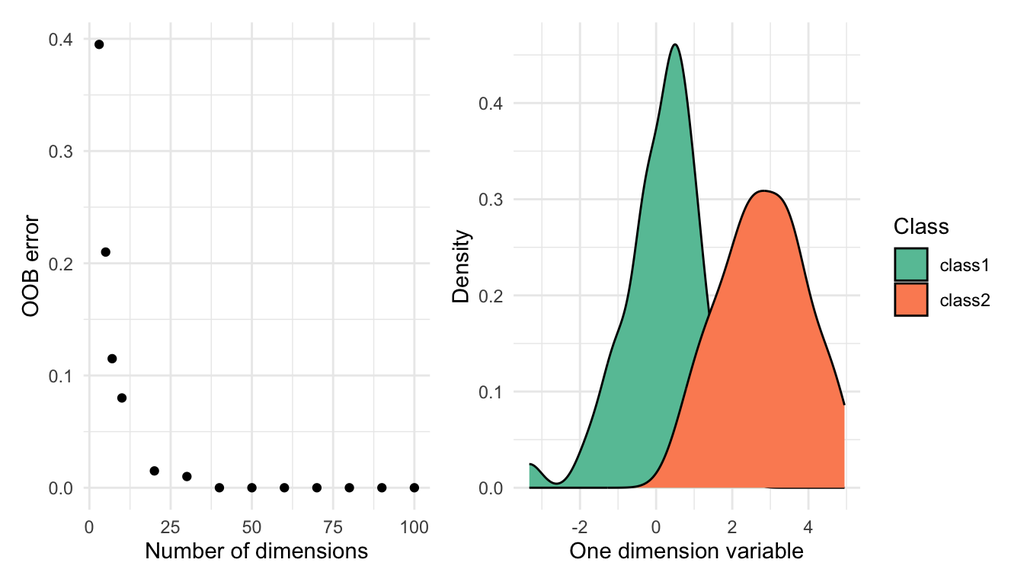

```r
tmp = data.frame(x=sim_2class[,1], y=sim_2class.y)
p2 = ggplot(tmp) +
    geom_density(aes(x=x, fill=y)) +
    xlab("One dimension variable") +
    ylab("Density") +
    scale_fill_brewer(name="Class", palette="Set2") +
    theme_minimal()
p1 + p2
```